# Untitled-1

```python
import numpy as np
import pandas as pd

from sklearn.model_selection import train_test_split
from sklearn.preprocessing import StandardScaler
from sklearn.metrics import accuracy_score
from sklearn.neural_network import MLPClassifier
```

```python
df = pd.read_csv("DS.csv")
df.shape
```

```
(4411, 160)
```

On introduit les variables x, y, z. On fait via str split

```python
if "xyz" in df.columns:
    xyz_split = df["xyz"].astype(str).str.split("__", expand=True)
    if xyz_split.shape[1] >= 3:
        df[["x", "y", "z"]] = xyz_split.iloc[:, :3]

required = ["x", "y", "z"]
missing = [c for c in required if c not in df.columns]
if missing:
    raise KeyError(f"Colonnes manquantes dans df: {missing}")

for c in required:
    df[c] = pd.to_numeric(df[c], errors="coerce")

df = df.dropna(subset=required).copy()
df = df.reset_index(drop=True)

print("Shape df:", df.shape)
df[["x", "y", "z"]].head()
```

```
Shape df: (4411, 160)
```

|  | x | y | z |
| --- | --- | --- | --- |
| 0 | 1.82 | 2.51 | 0.05 |
| 1 | 10.10 | 3.82 | 1.29 |
| 2 | 10.34 | 3.33 | 0.05 |
| 3 | 10.51 | 3.26 | 0.05 |
| 4 | 10.71 | 3.92 | 1.57 |

On veut maintenant, crées des voxels de taille 1 en 3D. x-> i, y-> j, z-> k ici les classes n'ont pas de sens, mais en baseline on peut tester pour voir les resultats que cela peut donner.

```python
import numpy as np
import pandas as pd

h = 1  # taille du voxel

for c in ["x", "y", "z"]:
    df[c] = pd.to_numeric(df[c], errors="coerce")

df = df.dropna(subset=["x", "y", "z"]).copy()

df["i"] = np.floor(df["x"] / h).astype(int)
df["j"] = np.floor(df["y"] / h).astype(int)
df["k"] = np.floor(df["z"] / h).astype(int)

Nx = df["i"].max() + 1 # nombres de voxels en x, y, z
Ny = df["j"].max() + 1
Nk = df["k"].max() + 1

df["class_id"] = df["i"] + Nx * df["j"] + Nx * Ny * df["k"]
target = df["class_id"]

X = df.drop(columns=[
    "i",
    "j",
    "k",
    "class_id",
    "x",
    "y",
    "z",
    "xyz"
], errors="ignore")

# Retirer toutes les colonnes non numeriques pour eviter l erreur du scaler
non_numeric_cols = X.select_dtypes(exclude=["number"]).columns.tolist()
X = X.drop(columns=non_numeric_cols, errors="ignore")


# Anti-fuite: ne garder que les vraies features RSSI
rssi_cols = [c for c in df.columns if c.startswith("max__Delta_rssi")]
if not rssi_cols:
    raise ValueError("Aucune colonne RSSI trouvee (prefixe max__Delta_rssi)")

X_small = df[rssi_cols].copy()

print("Nombre de classes :", target.nunique())
print("Nombre final de features RSSI :", X.shape[1])
print("Nombre de features RSSI selectionnees :", X_small.shape[1])
```

```
Nombre de classes : 74
Nombre final de features RSSI : 153
Nombre de features RSSI selectionnees : 24
```

```python
df['class_id'].nunique()
```

```
74
```

```
Nombre de classes: 74
Min/Max par classe: 10 / 160
Ratio de disparite (max/min): 16.00
Coefficient de variation: 0.587
```

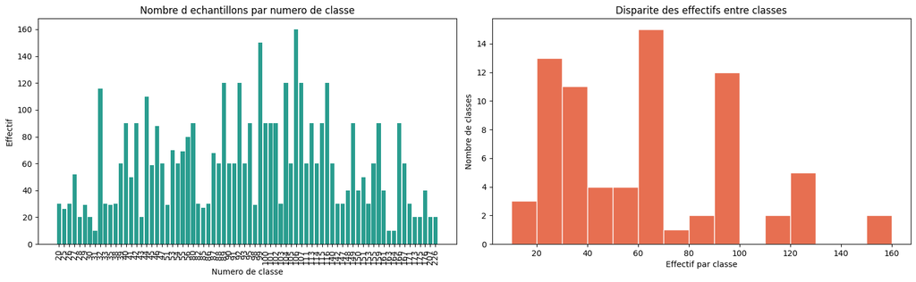

```python
import matplotlib.pyplot as plt

class_counts = target.value_counts().sort_index()

min_count = int(class_counts.min())
max_count = int(class_counts.max())
mean_count = float(class_counts.mean())
std_count = float(class_counts.std(ddof=0))
imbalance_ratio = max_count / max(min_count, 1)
cv = std_count / mean_count if mean_count > 0 else np.nan

print(f"Nombre de classes: {class_counts.shape[0]}")
print(f"Min/Max par classe: {min_count} / {max_count}")
print(f"Ratio de disparite (max/min): {imbalance_ratio:.2f}")
print(f"Coefficient de variation: {cv:.3f}")

fig, axes = plt.subplots(1, 2, figsize=(16, 5))

axes[0].bar(class_counts.index.astype(str), class_counts.values, color="#2a9d8f")
axes[0].set_title("Nombre d echantillons par numero de classe")
axes[0].set_xlabel("Numero de classe")
axes[0].set_ylabel("Effectif")
axes[0].tick_params(axis="x", labelrotation=90)

axes[1].hist(class_counts.values, bins=15, color="#e76f51", edgecolor="white")
axes[1].set_title("Disparite des effectifs entre classes")
axes[1].set_xlabel("Effectif par classe")
axes[1].set_ylabel("Nombre de classes")

plt.tight_layout()
plt.show()
```

Pour l'instant on fait une classif basique mais on pourrait aussi essayer en normalisant standars scaler ne regle pas le desiquilibre de classe. Donc deuxieme pîste d'amélioratino

```python
# Verification: class_id est cree a partir de la position voxel (i, j, k)
check_cols = ["xyz","x", "y", "z", "i", "j", "k", "class_id"]
display(df[check_cols].head(10))

labels_uniques = np.sort(df["class_id"].unique())
print("Nombre de labels uniques:", len(labels_uniques))
print("Premiers labels tries:", labels_uniques[:10])
```

|  | xyz | x | y | z | i | j | k | class_id |
| --- | --- | --- | --- | --- | --- | --- | --- | --- |
| 0 | 1.82__2.51__0.05 | 1.82 | 2.51 | 0.05 | 1 | 2 | 0 | 25 |
| 1 | 10.1__3.82__1.29 | 10.10 | 3.82 | 1.29 | 10 | 3 | 1 | 106 |
| 2 | 10.34__3.33__0.05 | 10.34 | 3.33 | 0.05 | 10 | 3 | 0 | 46 |
| 3 | 10.51__3.26__0.05 | 10.51 | 3.26 | 0.05 | 10 | 3 | 0 | 46 |
| 4 | 10.71__3.92__1.57 | 10.71 | 3.92 | 1.57 | 10 | 3 | 1 | 106 |
| 5 | 10.72__3.5__0.05 | 10.72 | 3.50 | 0.05 | 10 | 3 | 0 | 46 |
| 6 | 10.79__3.89__1.57 | 10.79 | 3.89 | 1.57 | 10 | 3 | 1 | 106 |
| 7 | 10.98__1.98__1.1300000000000001 | 10.98 | 1.98 | 1.13 | 10 | 1 | 1 | 82 |
| 8 | 11.01__3.87__1.08 | 11.01 | 3.87 | 1.08 | 11 | 3 | 1 | 107 |
| 9 | 11.16__3.95__1.07 | 11.16 | 3.95 | 1.07 | 11 | 3 | 1 | 107 |

```
Nombre de labels uniques: 74
Premiers labels tries: [20 25 26 27 28 29 30 31 32 33]
```

```python
X_train, X_test, y_train, y_test = train_test_split(
    X,
    target,
    test_size=0.2,
    random_state=42,
    stratify=target
)


print("Train:", X_train.shape)
print("Test:", X_test.shape)
print("Groupes train:", groups.iloc[train_idx].nunique())
print("Groupes test:", groups.iloc[test_idx].nunique())
```

```
Train: (3528, 153)
Test: (883, 153)
Groupes train: 355
Groupes test: 89
```

```python
from sklearn.model_selection import GroupShuffleSplit

# Anti-fuite: on separe par groupe de position xyz
groups = df.loc[X_small.index, "xyz"].astype(str) if "xyz" in df.columns else df.loc[X.index].index.astype(str)
gss = GroupShuffleSplit(n_splits=1, test_size=0.2, random_state=42)
train_idx, test_idx = next(gss.split(X_small, target, groups=groups))

X_train_small, X_test_small = X_small.iloc[train_idx], X_small.iloc[test_idx]
y_train_small, y_test_small = target.iloc[train_idx], target.iloc[test_idx]

print("Train:", X_train_small.shape)
print("Test:", X_test_small.shape)
print("Groupes train:", groups.iloc[train_idx].nunique())
print("Groupes test:", groups.iloc[test_idx].nunique())
```

```
Train: (3529, 24)
Test: (882, 24)
Groupes train: 355
Groupes test: 89
```

```python
scaler = StandardScaler()

X_train_scaled = scaler.fit_transform(X_train)
X_test_scaled = scaler.transform(X_test)

num_features = X_train_scaled.shape[1]
num_classes = target.nunique()

print("num_features =", num_features)
print("num_classes =", num_classes)
```

```
num_features = 153
num_classes = 74
```

tester que si on centre ? que si on reduit ?

```python
from sklearn.linear_model import LogisticRegression

RLog = LogisticRegression(
    max_iter=1000,
    solver="lbfgs",
    random_state=42
)

RLog.fit(X_train_scaled, y_train)

y_pred = RLog.predict(X_test_scaled)
acc_lr = accuracy_score(y_test, y_pred)

print("Logistic Regression accuracy:", acc_lr)
```

```
Logistic Regression accuracy: 0.637599093997735
```

```python
def decode_class_id(class_id, Nx, Ny):
    k = class_id // (Nx * Ny)
    remainder = class_id % (Nx * Ny)

    j = remainder // Nx
    i = remainder % Nx

    return i, j, k
```

```python
def voxel_center(class_id, Nx, Ny, h):
    i, j, k = decode_class_id(class_id, Nx, Ny)

    x = (i + 0.5) * h
    y = (j + 0.5) * h
    z = (k + 0.5) * h

    return np.array([x, y, z])
```

```python
true_coords = df.loc[X_test.index, ["x", "y", "z"]].to_numpy()

errors = []
predA3 = []
xyz_test = []
for pred_id, true_xyz in zip(y_pred, true_coords):

    pred_xyz = voxel_center(pred_id, Nx, Ny, h)

    err = np.linalg.norm(true_xyz - pred_xyz)

    errors.append(err)
    predA3.append(pred_xyz)
    xyz_test.append(true_xyz)
errors = np.array(errors)

print("Erreur moyenne :", errors.mean())
print("Erreur mediane :", np.median(errors))
print("Erreur max :", errors.max())
```

```
Erreur moyenne : 0.6349245013520493
Erreur mediane : 0.5591064299397746
Erreur max : 3.089741089476592
```

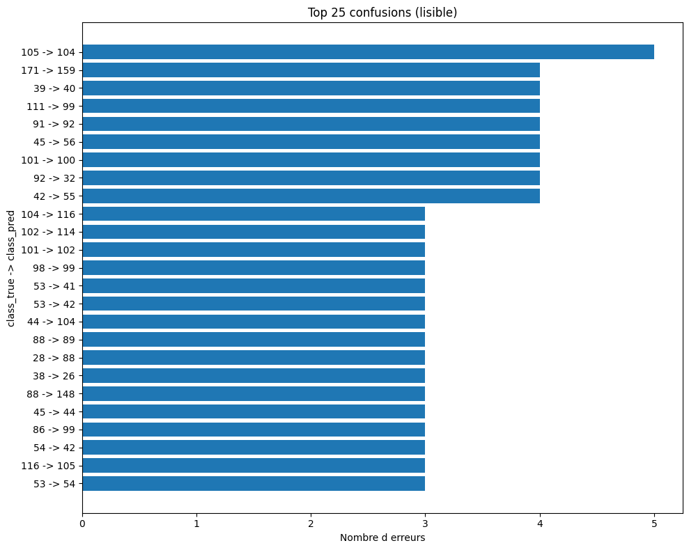

```python
if class_errors.empty:
    print("Aucune erreur de class_id a afficher.")
else:
    confusion_err = (
        class_errors.groupby(["class_true", "class_pred"])
        .size()
        .reset_index(name="count")
        .sort_values("count", ascending=False)
    )

    # 1) Top confusions en barres horizontales (plus lisible)
    top_n = 25
    top_err = confusion_err.head(top_n).copy()
    top_err["pair"] = top_err["class_true"].astype(str) + " -> " + top_err["class_pred"].astype(str)
    top_err = top_err.sort_values("count", ascending=True)

    plt.figure(figsize=(10, 8))
    plt.barh(top_err["pair"], top_err["count"])
    plt.title(f"Top {top_n} confusions (lisible)")
    plt.xlabel("Nombre d erreurs")
    plt.ylabel("class_true -> class_pred")
    plt.tight_layout()
    plt.show()
```

```python
rows_diff = []

for class_true, class_pred, xyz_true, xyz_pred in zip(
    np.asarray(y_test).astype(int),
    np.asarray(y_pred).astype(int),
    xyz_test,
    predA3
):

    dx = float(xyz_pred[0] - xyz_true[0])
    dy = float(xyz_pred[1] - xyz_true[1])
    dz = float(xyz_pred[2] - xyz_true[2])
    dist = float(np.linalg.norm([dx, dy, dz]))  # distance 3D

    rows_diff.append({
        "class_id_true": int(class_true),
        "class_id_pred": int(class_pred),

        "x_true": float(xyz_true[0]),
        "y_true": float(xyz_true[1]),
        "z_true": float(xyz_true[2]),

        "x_pred": float(xyz_pred[0]),
        "y_pred": float(xyz_pred[1]),
        "z_pred": float(xyz_pred[2]),

        "dx": dx,
        "dy": dy,
        "dz": dz,
        "distance": dist
    })

df_diff = pd.DataFrame(rows_diff)

print("Nombre total de lignes:", len(df_diff))

# erreurs > 1 m
df_diff_1m = df_diff[df_diff["distance"] > 1]

print("Nombre d'erreurs > 1 m:", len(df_diff_1m))

display(df_diff_1m.head(20))

print(df_diff_1m[[
    "class_id_true",
    "class_id_pred",
    "dx",
    "dy",
    "dz",
    "distance"
]].describe())
```

```
Nombre total de lignes: 883
Nombre d'erreurs > 1 m: 151
```

[output not shown]

[output not shown]

faudrait dig sur pq cette data donne ces erreurs maisjsp cmt faire

On réessaie le même modèle mais cette fois ci avec X small

```python
scaler = StandardScaler()

X_train_small_scaled = scaler.fit_transform(X_train_small)
X_test_small_scaled = scaler.transform(X_test_small)

num_features = X_train_small_scaled.shape[1]
num_classes = target.nunique()

print("num_features =", num_features)
print("num_classes =", num_classes)
```

```
num_features = 24
num_classes = 74
```

```python
from sklearn.linear_model import LogisticRegression

RLog = LogisticRegression(
    max_iter=1000,
    solver="lbfgs",
    random_state=42
)

RLog.fit(X_train_small_scaled, y_train_small)

y_pred = RLog.predict(X_test_small_scaled)
acc_lr = accuracy_score(y_test_small, y_pred)

print("Logistic Regression accuracy:", acc_lr)
```

```
Logistic Regression accuracy: 0.11791383219954649
```

aucun interet de continuer au vu de l'accuracy je pense.

On va essayer maintenant d'éviter davoir des classes sur répresenter (cm vu dans un des articles ou on enleve le surplus de data) :

```python
# Proportion de chaque class_id dans un DataFrame
df_prop_class = (
    df["class_id"]
    .value_counts()
    .rename_axis("class_id")
    .reset_index()
    .sort_values("class_id")
    .reset_index(drop=True)
)

print("Nombre de classes:", df_prop_class.shape[0])

display(df_prop_class.max())
mean = df_prop_class["class_id"].mean()
print("Moyenne:", mean)
```

```
Nombre de classes: 74
```

```
class_id    226
count       160
dtype: int64
```

```
Moyenne: 96.01351351351352
```

```python
df_prop_class = (
    df["class_id"]
    .value_counts()
    .rename_axis("class_id")
    .reset_index(name="count")
)

print("Nombre de classes:", df_prop_class.shape[0])

# afficher les classes les plus représentées
display(df_prop_class.sort_values("count", ascending=True).head(20))
```

```
Nombre de classes: 74
```

|  | class_id | count |
| --- | --- | --- |
| 72 | 163 | 10 |
| 73 | 164 | 10 |
| 71 | 31 | 10 |
| 65 | 43 | 20 |
| 64 | 30 | 20 |
| 66 | 173 | 20 |
| 68 | 207 | 20 |
| 67 | 28 | 20 |
| 69 | 226 | 20 |
| 70 | 175 | 20 |
| 63 | 25 | 26 |
| 62 | 85 | 27 |
| 60 | 35 | 29 |
| 61 | 98 | 29 |
| 58 | 29 | 29 |
| 59 | 51 | 29 |
| 57 | 20 | 30 |
| 47 | 26 | 30 |
| 53 | 153 | 30 |
| 52 | 171 | 30 |

```python
from sklearn.linear_model import LogisticRegression

RLog_balenced = LogisticRegression(
    max_iter=1000,
    solver="lbfgs",
    class_weight="balanced",
    random_state=42
)

RLog_balenced.fit(X_train_scaled, y_train)

y_pred_balenced = RLog_balenced.predict(X_test_scaled)
acc_lr_balenced = accuracy_score(y_test, y_pred_balenced)

print("Logistic Regression accuracy:", acc_lr_balenced)
```

```
Logistic Regression accuracy: 0.6138165345413363
```

etonnament l'accuracy descends ... néanmoins ce n'est pas une metrics fiable on va tester d'avantage.

```python
true_coords = df.loc[X_test.index, ["x", "y", "z"]].to_numpy()

errors = []
predA3_balenced = []
xyz_test_balenced = []
for pred_id, true_xyz in zip(y_pred_balenced, true_coords):

    pred_xyz_balenced = voxel_center(pred_id, Nx, Ny, h)

    err = np.linalg.norm(true_xyz - pred_xyz_balenced)

    errors.append(err)
    predA3_balenced.append(pred_xyz_balenced)
    xyz_test_balenced.append(true_xyz)
errors = np.array(errors)

print("Erreur moyenne :", errors.mean())
print("Erreur mediane :", np.median(errors))
print("Erreur max :", errors.max())
```

```
Erreur moyenne : 0.6782297965798247
Erreur mediane : 0.5707013229352109
Erreur max : 5.159515481128048
```

```python
rows_diff = []

for class_true, class_pred, xyz_true, xyz_pred_balenced in zip(
    np.asarray(y_test).astype(int),
    np.asarray(y_pred_balenced).astype(int),
    xyz_test_balenced,
    predA3_balenced
):
    dx = float(xyz_pred_balenced[0] - xyz_true[0])
    dy = float(xyz_pred_balenced[1] - xyz_true[1])
    dz = float(xyz_pred_balenced[2] - xyz_true[2])
    dist = float(np.linalg.norm([dx, dy, dz]))

    rows_diff.append({
        "class_id_true": int(class_true),
        "class_id_pred": int(class_pred),
        "x_true": float(xyz_true[0]),
        "y_true": float(xyz_true[1]),
        "z_true": float(xyz_true[2]),
        "x_pred": float(xyz_pred_balenced[0]),
        "y_pred": float(xyz_pred_balenced[1]),
        "z_pred": float(xyz_pred_balenced[2]),
        "dx": dx,
        "dy": dy,
        "dz": dz,
        "distance": dist
    })

df_diff_balenced = pd.DataFrame(rows_diff)

print("Nombre total de lignes:", len(df_diff_balenced))

df_diff_balenced_1p7m = df_diff_balenced[df_diff_balenced["distance"] > 5]
print("Nombre d erreurs > 1.7 m:", len(df_diff_balenced_1p7m))

display(df_diff_balenced_1p7m.head(20))

print(df_diff_balenced_1p7m[[
    "class_id_true",
    "class_id_pred",
    "dx",
    "dy",
    "dz",
    "distance"
]].describe())
```

```
Nombre total de lignes: 883
Nombre d erreurs > 1.7 m: 1
```

|  | class_id_true | class_id_pred | x_true | y_true | z_true | x_pred | y_pred | z_pred | dx | dy | dz | distance |
| --- | --- | --- | --- | --- | --- | --- | --- | --- | --- | --- | --- | --- |
| 600 | 55 | 26 | 7.39 | 4.12 | 0.79 | 2.5 | 2.5 | 0.5 | -4.89 | -1.62 | -0.29 | 5.159515 |

```
       class_id_true  class_id_pred    dx    dy    dz  distance
count            1.0            1.0  1.00  1.00  1.00  1.000000
mean            55.0           26.0 -4.89 -1.62 -0.29  5.159515
std              NaN            NaN   NaN   NaN   NaN       NaN
min             55.0           26.0 -4.89 -1.62 -0.29  5.159515
25%             55.0           26.0 -4.89 -1.62 -0.29  5.159515
50%             55.0           26.0 -4.89 -1.62 -0.29  5.159515
75%             55.0           26.0 -4.89 -1.62 -0.29  5.159515
max             55.0           26.0 -4.89 -1.62 -0.29  5.159515
```

on observe pas des résultat proprement meilleurs, néanmoins on peut également tester d'autre méthode.

### CV ?

```python
from sklearn.linear_model import LogisticRegression
from sklearn.model_selection import cross_val_score
from sklearn.metrics import accuracy_score

RLog_cv = LogisticRegression(
    max_iter=1000,
    solver="lbfgs",
    random_state=53
)

# Cross-validation (5 folds)
cv_scores = cross_val_score(RLog_cv, X_train_scaled, y_train, cv=8)

print("CV accuracy scores:", cv_scores)
print("CV mean accuracy:", cv_scores.mean())

# entraînement final
RLog_cv.fit(X_train_scaled, y_train)

y_pred_cv = RLog_cv.predict(X_test_scaled)
acc_lr_cv = accuracy_score(y_test, y_pred_cv)

print("Test accuracy:", acc_lr_cv)
```

```
CV accuracy scores: [0.6122449  0.62131519 0.61451247 0.61451247 0.57142857 0.60997732
 0.60770975 0.58049887]
CV mean accuracy: 0.6040249433106577
Test accuracy: 0.637599093997735
```

```python
true_coords = df.loc[X_test.index, ["x", "y", "z"]].to_numpy()

errors = []
predA3_cv = []
xyz_test_cv = []
for pred_id, true_xyz in zip(y_pred_cv, true_coords):

    pred_xyz_cv = voxel_center(pred_id, Nx, Ny, h)

    err = np.linalg.norm(true_xyz - pred_xyz_cv)

    errors.append(err)
    predA3_cv.append(pred_xyz_cv)
    xyz_test_cv.append(true_xyz)
errors = np.array(errors)

print("Erreur moyenne :", errors.mean())
print("Erreur mediane :", np.median(errors))
print("Erreur max :", errors.max())
```

```
Erreur moyenne : 0.6349245013520493
Erreur mediane : 0.5591064299397746
Erreur max : 3.089741089476592
```

lerreur max descend de 5 a 3 ? positif :)

```python
rows_diff = []

for class_true, class_pred, xyz_true, xyz_pred_cv in zip(
    np.asarray(y_test).astype(int),
    np.asarray(y_pred_cv).astype(int),
    xyz_test_cv,
    predA3_cv
):
    dx = float(xyz_pred_cv[0] - xyz_true[0])
    dy = float(xyz_pred_cv[1] - xyz_true[1])
    dz = float(xyz_pred_cv[2] - xyz_true[2])
    dist = float(np.linalg.norm([dx, dy, dz]))

    rows_diff.append({
        "class_id_true": int(class_true),
        "class_id_pred": int(class_pred),
        "x_true": float(xyz_true[0]),
        "y_true": float(xyz_true[1]),
        "z_true": float(xyz_true[2]),
        "x_pred": float(xyz_pred_cv[0]),
        "y_pred": float(xyz_pred_cv[1]),
        "z_pred": float(xyz_pred_cv[2]),
        "dx": dx,
        "dy": dy,
        "dz": dz,
        "distance": dist
    })

df_diff_balenced = pd.DataFrame(rows_diff)

print("Nombre total de lignes:", len(df_diff_balenced))

df_diff_balenced_1p7m = df_diff_balenced[df_diff_balenced["distance"] > 1.3]
print("Nombre d erreurs > 1.7 m:", len(df_diff_balenced_1p7m))

display(df_diff_balenced_1p7m.head(20))

print(df_diff_balenced_1p7m[[
    "class_id_true",
    "class_id_pred",
    "dx",
    "dy",
    "dz",
    "distance"
]].describe())
```

```
Nombre total de lignes: 883
Nombre d erreurs > 1.7 m: 38
```

|  | class_id_true | class_id_pred | x_true | y_true | z_true | x_pred | y_pred | z_pred | dx | dy | dz | distance |
| --- | --- | --- | --- | --- | --- | --- | --- | --- | --- | --- | --- | --- |
| 4 | 53 | 55 | 5.55 | 4.09 | 0.42 | 7.5 | 4.5 | 0.5 | 1.95 | 0.41 | 0.08 | 1.994242 |
| 22 | 101 | 102 | 5.04 | 3.83 | 1.70 | 6.5 | 3.5 | 1.5 | 1.46 | -0.33 | -0.20 | 1.510132 |
| 24 | 176 | 105 | 8.47 | 4.52 | 2.35 | 9.5 | 3.5 | 1.5 | 1.03 | -1.02 | -0.85 | 1.680417 |
| 61 | 90 | 163 | 6.31 | 2.75 | 1.77 | 7.5 | 3.5 | 2.5 | 1.19 | 0.75 | 0.73 | 1.584771 |
| 84 | 56 | 45 | 8.87 | 4.79 | 0.70 | 9.5 | 3.5 | 0.5 | 0.63 | -1.29 | -0.20 | 1.449483 |
| 130 | 105 | 106 | 9.30 | 3.70 | 1.02 | 10.5 | 3.5 | 1.5 | 1.20 | -0.20 | 0.48 | 1.307823 |
| 138 | 164 | 151 | 8.41 | 3.95 | 2.29 | 7.5 | 2.5 | 2.5 | -0.91 | -1.45 | 0.21 | 1.724732 |
| 164 | 44 | 55 | 8.74 | 3.46 | 0.05 | 7.5 | 4.5 | 0.5 | -1.24 | 1.04 | 0.45 | 1.679792 |
| 177 | 207 | 159 | 3.61 | 2.39 | 3.21 | 3.5 | 3.5 | 2.5 | -0.11 | 1.11 | -0.71 | 1.322233 |
| 179 | 93 | 166 | 9.57 | 2.71 | 1.96 | 10.5 | 3.5 | 2.5 | 0.93 | 0.79 | 0.54 | 1.334391 |
| 208 | 115 | 91 | 7.73 | 4.45 | 1.67 | 7.5 | 2.5 | 1.5 | -0.23 | -1.95 | -0.17 | 1.970863 |
| 238 | 42 | 55 | 6.16 | 3.97 | 0.05 | 7.5 | 4.5 | 0.5 | 1.34 | 0.53 | 0.45 | 1.509636 |
| 242 | 54 | 113 | 6.16 | 4.08 | 0.05 | 5.5 | 4.5 | 1.5 | -0.66 | 0.42 | 1.45 | 1.647574 |
| 278 | 104 | 153 | 8.79 | 3.32 | 1.67 | 9.5 | 2.5 | 2.5 | 0.71 | -0.82 | 0.83 | 1.365796 |
| 287 | 101 | 148 | 5.69 | 3.07 | 1.06 | 4.5 | 2.5 | 2.5 | -1.19 | -0.57 | 1.44 | 1.953100 |
| 320 | 176 | 105 | 8.47 | 4.52 | 2.02 | 9.5 | 3.5 | 1.5 | 1.03 | -1.02 | -0.52 | 1.540032 |
| 322 | 102 | 115 | 6.83 | 3.36 | 1.34 | 7.5 | 4.5 | 1.5 | 0.67 | 1.14 | 0.16 | 1.331953 |
| 355 | 116 | 33 | 8.47 | 4.52 | 1.05 | 9.5 | 2.5 | 0.5 | 1.03 | -2.02 | -0.55 | 2.333195 |
| 357 | 148 | 89 | 4.41 | 2.39 | 2.36 | 5.5 | 2.5 | 1.5 | 1.09 | 0.11 | -0.86 | 1.392767 |
| 359 | 114 | 115 | 6.16 | 4.08 | 1.02 | 7.5 | 4.5 | 1.5 | 1.34 | 0.42 | 0.48 | 1.484049 |

```
       class_id_true  class_id_pred         dx         dy         dz  \
count      38.000000      38.000000  38.000000  38.000000  38.000000
mean       99.105263     104.052632   0.171579  -0.260789   0.320526
std        46.136571      49.277454   1.031746   1.129090   0.698516
min        20.000000      20.000000  -2.190000  -3.020000  -0.880000
25%        56.000000      55.000000  -0.660000  -1.020000  -0.192500
50%       101.000000     105.000000   0.070000  -0.095000   0.450000
75%       116.000000     151.000000   1.030000   0.560000   0.562500
max       207.000000     173.000000   1.950000   2.040000   1.660000

        distance
count  38.000000
mean    1.676311
std     0.383277
min     1.307823
25%     1.407189
50%     1.528617
75%     1.919090
max     3.089741
```

## AAAAAAAA

```python
model = MLPClassifier(
    hidden_layer_sizes=(128, 64),
    activation="relu",
    solver="adam",
    learning_rate_init=1e-3,
    batch_size=64,
    max_iter=200,
    random_state=42,
    early_stopping=True,
    validation_fraction=0.1,
    n_iter_no_change=15
)

model.fit(X_train_scaled, y_train)

test_acc = model.score(X_test_scaled, y_test)

print("Test accuracy:", test_acc)
```

```
Test accuracy: 0.8187995469988675
```

```python
proba = model.predict_proba(X_test_scaled)

y_pred = model.predict(X_test_scaled)

y_true = y_test.to_numpy()

acc = accuracy_score(y_true, y_pred)

print("Accuracy class_id:", acc)
```

```
Accuracy class_id: 0.8187995469988675
```